# Capstone Project

Ryan Ramirez

2023-01-05

## Overview

Cyclistic is a substantial bike-share program that has multiple bike stations around the greater Chicago area. As the number of users grow, the company wants to explore how they can increase the number of annual memberships. Specifically, we will focus on the behaviors of casual members to create recommendations that will encourage their transition into an annual member.

## Processing and Cleaning the Data

The data was gathered from a public source and made available by Motivate International Inc. found on the AWS cloud platform.

Since this is public data,there is no personal info containing the riders bank details or home address.Each ride has a unique ride ID, however, the type of membership is shown to continue our analysis.

Prior to importing the data sets the following steps were done on Excel:

1. Calculated the ride duration for each ride in “hh:mm:ss” format
2. Added a column indicating the day of the week in numerical format

### Using R for data cleaning

The following was done with the imported csv files from Excel:

- The *ride_length* column was converted to a numeric double indicating seconds
- All NA’s were omitted from each monthly dataset

The data includes rows where the station name or end staion names are missing, but this will be analyzed later.

The monthly data frames were combined together to create a data frame observing the entire year of 2022. This data frame will be used for most of the analysis.

New columns were added to the year data set including the year, month, and date for each bike ride.

## Analysis

### Monthly Data

The following graph shows that there are less riders in the Winter months compared to Spring and Summer. This observation can be seen for both casual and annual members.

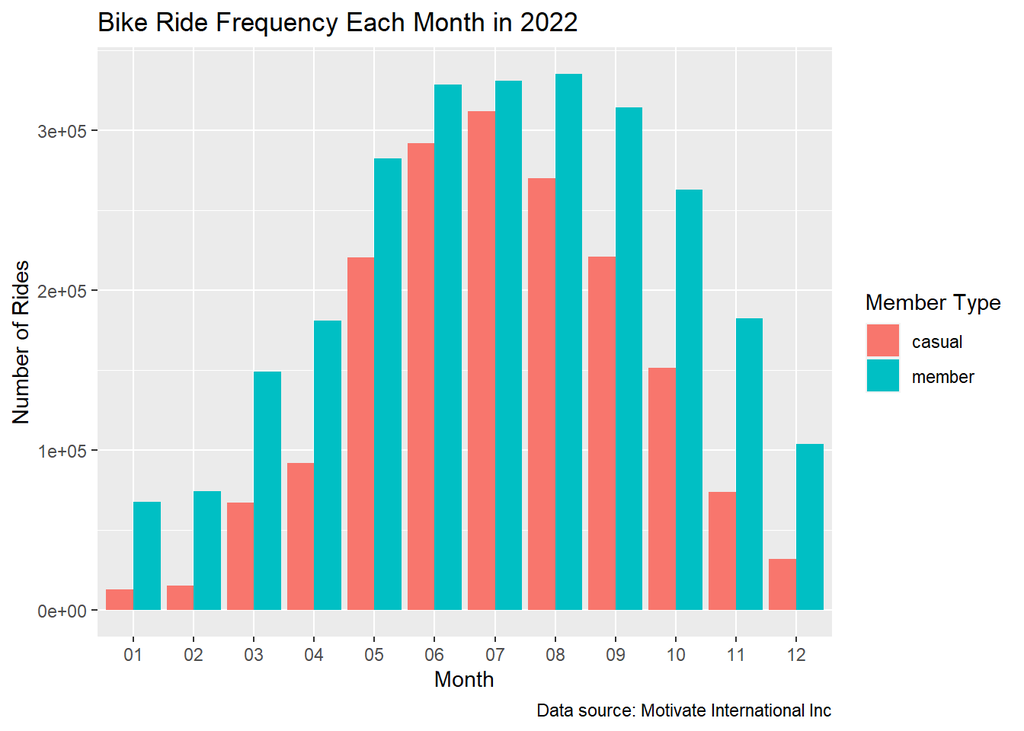

### Daily Data

The following graph shows that casual members rode more on the weekends compared to the weekdays. Annual members appeared to rode more on the weekdays compared to the the weekends. However, overall we see that annual riders bike more consistently across the whole week compared to casual riders.

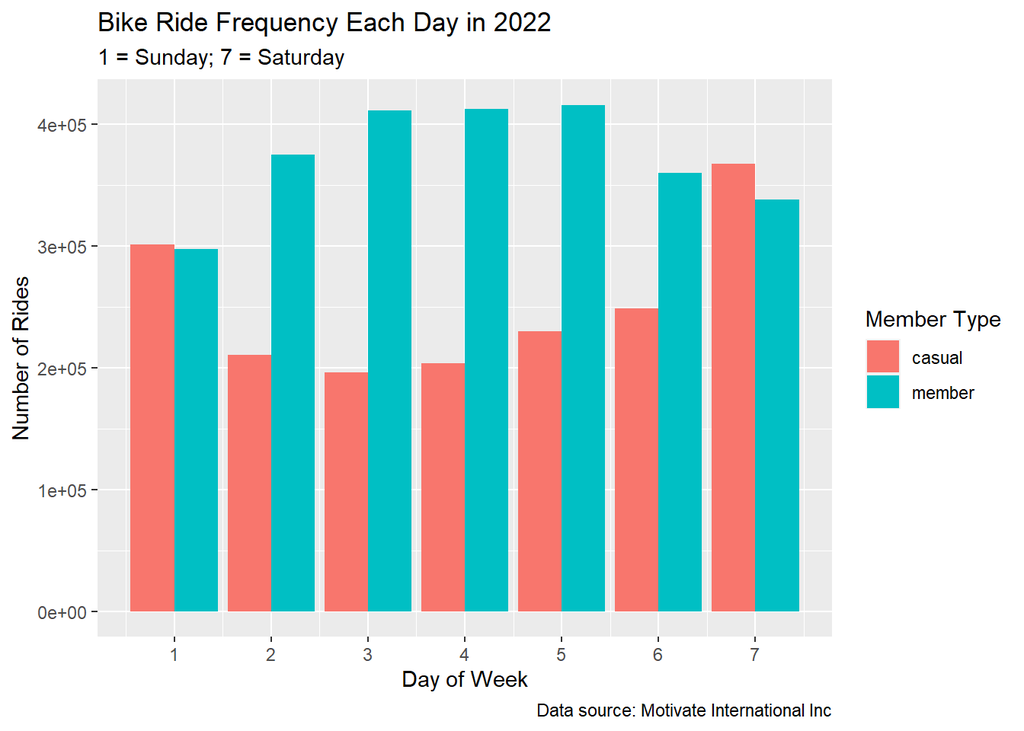

### Average Ride Length: Casual VS Member

Compute the average ride length for both casual and annual members. The plots below show the average ride length for the year, month, and day of the week. The pattern we find is that the average ride length across the whole year, month, and days of the week. The average ride length of the year for casual riders was 23.84 minutes and annual riders was 12.45 minutes.

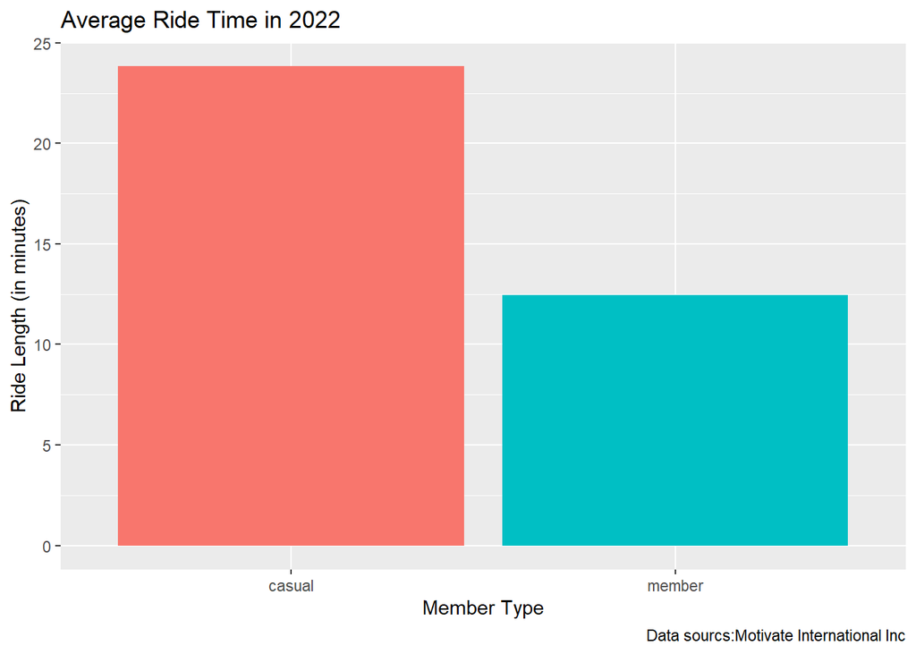

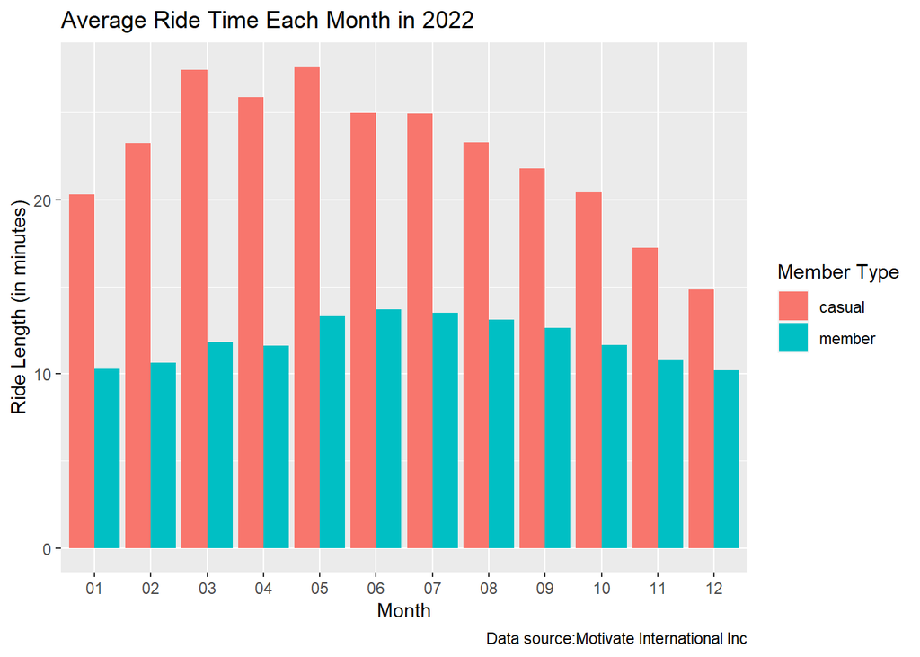

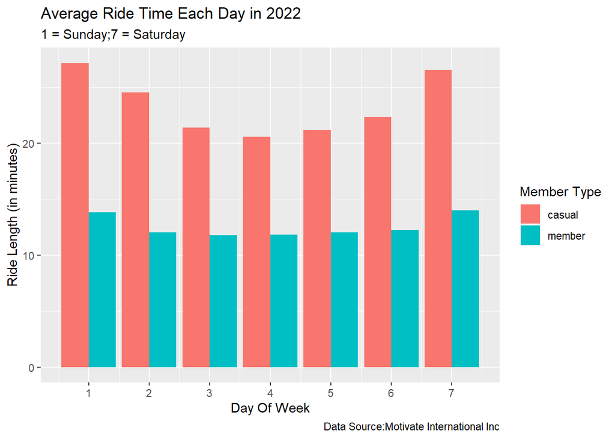

```
## # A tibble: 2 x 2
##   member_casual avg_ride_time
##   <chr>                 <dbl>
## 1 casual                 23.8
## 2 member                 12.5
```

### Electric Vs Classic Bikes

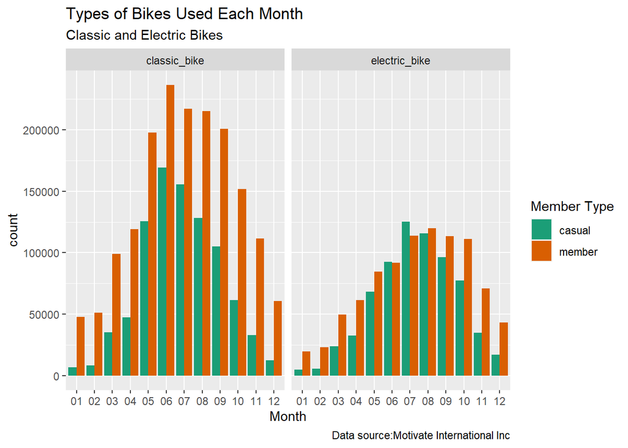

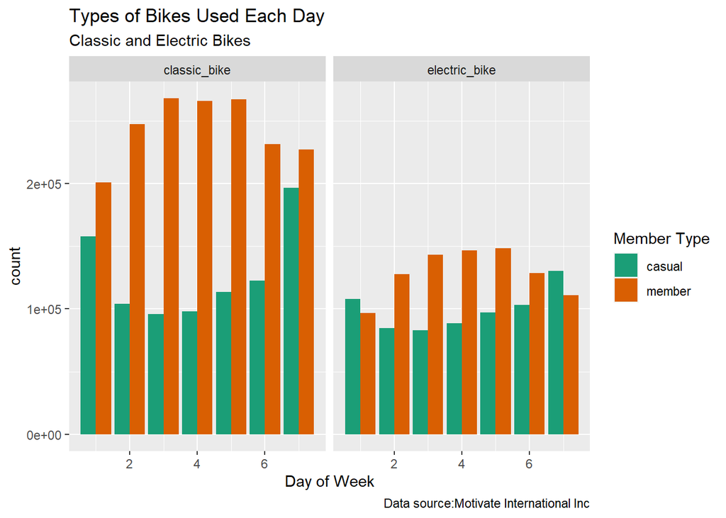

### Popular Bike Routes

Investigated popular routes by both casual and annual members. This takes account of bike rides where start and end stations are the same to consider all routes.

```
## # A tibble: 6 x 5
##   start_station_name               end_station_name member_casual total avg_time
##   <chr>                            <chr>            <chr>         <int>    <dbl>
## 1 Streeter Dr & Grand Ave          Streeter Dr & G~ casual        10631     40.7
## 2 DuSable Lake Shore Dr & Monroe ~ DuSable Lake Sh~ casual         6615     34.5
## 3 DuSable Lake Shore Dr & Monroe ~ Streeter Dr & G~ casual         5100     27.9
## 4 Michigan Ave & Oak St            Michigan Ave & ~ casual         4612     45.1
## 5 Millennium Park                  Millennium Park  casual         4060     37.7
## 6 Montrose Harbor                  Montrose Harbor  casual         2939     49.6
```

```
## # A tibble: 6 x 5
##   start_station_name       end_station_name         member_casual total avg_time
##   <chr>                    <chr>                    <chr>         <int>    <dbl>
## 1 Ellis Ave & 60th St      University Ave & 57th St member         5848     4.96
## 2 University Ave & 57th St Ellis Ave & 60th St      member         5544     4.96
## 3 Ellis Ave & 60th St      Ellis Ave & 55th St      member         5278     5.23
## 4 Ellis Ave & 55th St      Ellis Ave & 60th St      member         4745     5.32
## 5 State St & 33rd St       Calumet Ave & 33rd St    member         3268     4.82
## 6 Calumet Ave & 33rd St    State St & 33rd St       member         3215     4.16
```

Created a csv file to import into Tableau and create a data visualization of Chicago and popular start stations and routes used by casual and annual members. We can find that more casual riders are found in tourist areas such as downtown or near famous landmarks.

### Tableau Visualization

You can click here to observe the dashboard: [Chicago Bike Routes and Stations](https://public.tableau.com/app/profile/ryan6592/viz/ChicagoCyclitic/Dashboard1#1)

## Conclusion

Based on the analysis on the data of bike rides in 2022, we found the following:

We can assume that there might be a larger frequency of member bike rides because it can be used more for commuting to work from Monday through Friday. We also take account the each ride ID is different but we do not know if it is the same individual riding different times each day. However, we only wanted to observe the frequency of bike rides according to type of membership.

In conclusion, some recommendations may include the following:

- Offer first 6 months for free for annual membership. This will be in handy during the Spring and Summer months where there are more bike rides
- Digital marketing on travel websites or in partnership with travel agencies for tourists coming to Chicago
- Create more advertising near popular start stations for casual riders; use tourist incentives such as perks with annual membership
- Market towards residents or workers who commute to work; incentivize biking for casual riders who go to work